# DMHR Assignment 2018

### GitHub link: https://github.com/TSRC3/DMHR-Assignment-2018

```python
#Preliminaries.

import pandas as pd
import numpy as np

%matplotlib inline
import matplotlib.pyplot as plt

import datetime
```

```python
#Import files.

practices_csv = 'https://s3.eu-west-2.amazonaws.com/dmhr-data/practices_Dec2015.csv'
prescribing_csv = 'https://s3.eu-west-2.amazonaws.com/dmhr-data/prescribing_Dec2015.csv'
demoinfo_csv = 'https://digital.nhs.uk/media/28273/Numbers-of-Patients-Registered-at-a-GP-Practice-Jan-2016-GP-Practice-and-quinary-age-groups/Any/gp-reg-patients-prac-quin-age'
ONS_csv = 'https://s3.eu-west-2.amazonaws.com/dmhr-data/postcodes.csv'
EDI_csv = 'https://s3.eu-west-2.amazonaws.com/dmhr-data/deprivation-by-postcode.csv'
mortrate_csv = 'https://s3.eu-west-2.amazonaws.com/dmhr-data/NHSOF_1.1_I00656_D.csv'
canadaFluTrends_txt = 'https://www.google.org/flutrends/about/data/flu/ca/data.txt'
newzealandFluTrends_txt = 'https://www.google.org/flutrends/about/data/flu/nz/data.txt'

practices_df = pd.read_csv(practices_csv, names=['Period', 'Practice', 'Practice name', 'Address 1', 'Address 2', 'Address 3', 'County', 'Postcode', 'Empty'])
prescribing_df = pd.read_csv(prescribing_csv)
demoinfo_df = pd.read_csv(demoinfo_csv)
ONS_df = pd.read_csv(ONS_csv)
EDI_df = pd.read_csv(EDI_csv)
mortrate_df = pd.read_csv(mortrate_csv)
canadaFluTrends_df = pd.read_csv(canadaFluTrends_txt, sep=',', header = 8)
newzealandFluTrends_df = pd.read_csv(newzealandFluTrends_txt, sep=',', header = 8)
```

```python
#Rename column names in prescribing_df.

prescribing_df.columns = ['SHA', 'PCT', 'Practice', 'BNF Code', 'BNF Name', 'Items', 'NIC', 'Act Cost', 'Quantity', 'Period', 'Empty']
```

# Assignment A

### Question 1: Identify all GP practices and produce a table with the total number of prescriptions and their total actual cost (using the ACT COST column).

```python
#Merge practices_df and prescribing_df.
merged = pd.merge(practices_df, prescribing_df, left_on='Practice', right_on='Practice')

#Identify Bristol GP practices.
bristol_data = merged.loc[merged['Postcode'].str.startswith('BS')]

#Group bristol_data by 'Practice'.
bristol_df1 = bristol_data.groupby(['Practice', 'Practice name'], as_index=False).sum()

#Tabulate total number of prescriptions and total actual cost for each Bristol GP practice.
bristol_df2 = pd.DataFrame({'Bristol GP Practice' : pd.Categorical(bristol_df1['Practice']),
                            'Practice Name' : pd.Categorical(bristol_df1['Practice name']),
                            'Total Number of Prescriptions' : pd.Series(bristol_df1['Items']),
                            'Total Actual Cost' : pd.Series(bristol_df1['Act Cost'])})

bristol_df2 = bristol_df2[['Bristol GP Practice', 'Practice Name', 'Total Number of Prescriptions', 'Total Actual Cost']]
bristol_df2.head()
```

|  | Bristol GP Practice | Practice Name | Total Number of Prescriptions | Total Actual Cost |
| --- | --- | --- | --- | --- |
| 0 | L81004 | PORTISHEAD MEDICAL GROUP | 28314 | 228511.10 |
| 1 | L81006 | THE GREEN PRACTICE AT WHITCHURCH H C | 6762 | 51891.20 |
| 2 | L81007 | THE SOUTHVILLE SURGERY | 8480 | 61316.17 |
| 3 | L81008 | SHIREHAMPTON GROUP PRACTICE | 20139 | 128469.59 |
| 4 | L81009 | STOCKWOOD MEDICAL CENTRE | 23800 | 158186.32 |

### Question 2: Find the top ten most/least frequently prescribed medications across all practices. What is their total actual cost and how does that compare to the overall actual costs of each practice and of the entire city?

```python
#Group bristol_data by 'BNF Code' and BNF Name'.
bristol_df3 = bristol_data.groupby(['BNF Code', 'BNF Name'], as_index=False).sum()

#Calculate the top ten most/least frequently prescribed medications across all practices.
bristol_df4 = pd.DataFrame({'BNF Code' : pd.Categorical(bristol_df3['BNF Code']),
                            'BNF Name' : pd.Categorical(bristol_df3['BNF Name']),
                            'Total Number of Prescriptions' : pd.Series(bristol_df3['Items']),
                            'Total Actual Cost': pd.Series(bristol_df3['Act Cost'])})

bristol_df4 = bristol_df4[['BNF Code', 'BNF Name', 'Total Number of Prescriptions', 'Total Actual Cost']]
bristol_sorted = bristol_df4.sort_values('Total Number of Prescriptions', axis=0, ascending=False, kind='quicksort', na_position='last')

bristol_top10 = bristol_sorted.head(10)
bristol_top10
```

|  | BNF Code | BNF Name | Total Number of Prescriptions | Total Actual Cost |
| --- | --- | --- | --- | --- |
| 135 | 0103050P0AAAAAA | Omeprazole_Cap E/C 20mg | 55667 | 85119.08 |
| 1945 | 0407010H0AAAMAM | Paracet_Tab 500mg | 34269 | 110617.91 |
| 1122 | 0212000Y0AAADAD | Simvastatin_Tab 40mg | 25676 | 32618.20 |
| 1028 | 0209000A0AAABAB | Aspirin Disper_Tab 75mg | 23714 | 21476.89 |
| 810 | 0206020A0AAAAAA | Amlodipine_Tab 5mg | 23007 | 26231.45 |
| 400 | 0202010B0AAABAB | Bendroflumethiazide_Tab 2.5mg | 19152 | 21967.36 |
| 1075 | 0212000B0AAABAB | Atorvastatin_Tab 20mg | 19032 | 31469.37 |
| 3084 | 0601022B0AAABAB | Metformin HCl_Tab 500mg | 18475 | 82494.03 |
| 1157 | 0301011R0BEAIAP | Ventolin_Evohaler 100mcg (200 D) | 17592 | 39290.92 |
| 5761 | 1404000H0AAAFAF | Influenza_Vac Inact 0.5ml Pfs | 17354 | 105743.39 |

```python
bristol_bottom10 = bristol_sorted.tail(10)
bristol_bottom10
```

|  | BNF Code | BNF Name | Total Number of Prescriptions | Total Actual Cost |
| --- | --- | --- | --- | --- |
| 429 | 0202030C0AAASAS | Amiloride HCl_Oral Soln 5mg/5ml S/F | 1 | 69.08 |
| 5993 | 20030100260 | Cosmopor E 5cm x 7.2cm Adh Dress Pfa | 1 | 0.75 |
| 5972 | 20030100165 | Ster Dress Pack + Non-Wov Pads Vernaid | 1 | 5.89 |
| 5976 | 20030100177 | OpSite Flexigrid 12cm x 12cm VP Adh Film | 1 | 10.46 |
| 424 | 0202020L0BZACBP | Frusol_Oral Soln 50mg/5ml S/F | 1 | 15.58 |
| 5980 | 20030100185 | Bioclusive 10.2cm x 12.7cm VP Adh Film D | 1 | 14.25 |
| 5981 | 20030100197 | Tegaderm IV 7cm x 8.5cm Peri Line VP Adh | 1 | 10.92 |
| 5984 | 20030100213 | Primapore 10cm x 25cm Pfa + Adh Border D | 1 | 4.64 |
| 5988 | 20030100222 | C-View 15cm x 20cm VP Adh Film Dress | 1 | 43.64 |
| 601 | 0205051ACAAABAB | Perindopril/Amlodipine_Tab 4mg/10mg | 1 | 9.26 |

```python
#Calculate the total actual cost of the top 10 and bottom 10 most prescribed medications.
total_actcost_10 = bristol_top10['Total Actual Cost'].sum() + bristol_bottom10['Total Actual Cost'].sum()

#Tabulate the values.
totalactcost_10 = pd.DataFrame({'Position' : pd.Categorical(['Top 10 and Bottom 10']),
                                'Total Actual Cost' : pd.Series(total_actcost_10)})

#Calculate the total actual cost of medication in Bristol.
bristol_total_actcost = bristol_df2['Total Actual Cost'].sum()
```

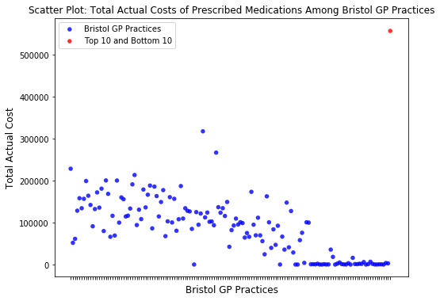

```python
#Create a scatter plot to compare the total actual cost of the top 10 and bottom 10 most prescribed medications with the overall actual costs of each practice.
top_actcost = (bristol_df2['Bristol GP Practice'], bristol_df2['Total Actual Cost'])
bristol_actcost = (totalactcost_10['Position'], totalactcost_10['Total Actual Cost'])

data = (top_actcost, bristol_actcost)
colours = ("blue", "red")
groups = ("Bristol GP Practices", "Top 10 and Bottom 10")


fig = plt.figure(figsize=(8, 6))
ax = fig.add_subplot(1, 1, 1, axisbg="1.0")

for data, color, group in zip(data, colours, groups):
    x, y = data
    ax.scatter(x, y, alpha=0.8, c=color, edgecolors='none', s=30, label=group)

ax.set_xlabel("Bristol GP Practices",fontsize=12)
ax.set_ylabel("Total Actual Cost",fontsize=12)
ax.set_xticklabels([])

plt.title('Scatter Plot: Total Actual Costs of Prescribed Medications Among Bristol GP Practices')
plt.legend(loc=2)
plt.show()
```

```python
#Tabulate the total actual cost of the top 10 and bottom 10 most prescribed medications with the overall actual cost of Bristol.
totactcost = pd.DataFrame({'Level' : pd.Categorical(["Top 10 and Bottom 10", "National"]),
                           'Total Actual Cost' : pd.Series([total_actcost_10, bristol_total_actcost])})

totactcost = totactcost[['Level', 'Total Actual Cost']]
totactcost
```

|  | Level | Total Actual Cost |
| --- | --- | --- |
| 0 | Top 10 and Bottom 10 | 557213.07 |
| 1 | National | 12630688.08 |

```
Text(0,0.5,'Total Actual Cost')
```

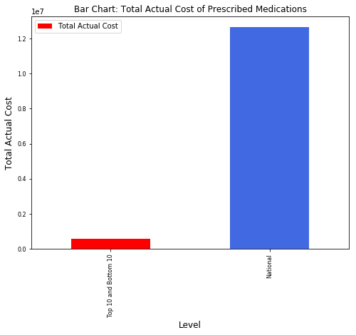

```python
#Create a bar chart to compare the total actual cost of the top 10 and bottom 10 most prescribed medications with the overall actual cost of Bristol.
ax = totactcost[['Level', 'Total Actual Cost']].plot(kind='bar', x='Level', y='Total Actual Cost', title="Bar Chart: Total Actual Cost of Prescribed Medications", stacked=False, color=['red', 'royalblue'], figsize=(8,6), legend=True, fontsize=8)
ax.set_xlabel("Level",fontsize=12)
ax.set_ylabel("Total Actual Cost",fontsize=12)
```

### Question 3: Find the top ten most expensive medications and calculate their actual cost.

```python
#Make a subset of bristol_data without '0' in 'Quantity'.
bristol_data2 = bristol_data.loc[bristol_data['Quantity'] != 0]

#Make a new column 'Cost Per Drug' in bristol_data2 and sort it in descending order.
bristol_data2['Cost Per Drug'] = (bristol_data2['Act Cost'] / bristol_data2['Quantity']).round(2)
bristol_sorted = bristol_data2.sort_values('Cost Per Drug', axis=0, ascending=False, kind='quicksort', na_position='last').drop_duplicates(subset=['BNF Code'], keep='first', inplace=False)

#Calculate the top ten most expensive medications and calculate their actual cost.
bristol_top10_cost = bristol_sorted.head(10)
```

```python
#Tabulate the values.
bristol_df5 = pd.DataFrame({'BNF Code' : pd.Categorical(bristol_top10_cost['BNF Code']),
                            'BNF Name' : pd.Categorical(bristol_top10_cost['BNF Name']),
                            'Cost Per Drug' : pd.Series(bristol_top10_cost['Cost Per Drug']),
                            'Actual Cost' : pd.Series(bristol_top10_cost['Act Cost'])})

bristol_df5 = bristol_df5[['BNF Code', 'BNF Name', 'Cost Per Drug', 'Actual Cost']]
bristol_df5
```

|  | BNF Code | BNF Name | Cost Per Drug | Actual Cost |
| --- | --- | --- | --- | --- |
| 6114558 | 0803043N0BBAGAG | Sandostatin LAR_Inj 20mg Vl + Dil | 739.12 | 739.12 |
| 6066534 | 0803042S0BCAAAB | Decapeptyl SR_Inj 22.5mg Vl + Dil | 382.83 | 382.83 |
| 6114557 | 0803042S0AAABAB | Triptorelin Embon_Inj 22.5mg Vl + Dil | 382.80 | 382.80 |
| 6161284 | 0402020ABAAADAD | Paliperidone_Inj 150mg/1.5ml Pfs | 363.02 | 363.02 |
| 6166534 | 0606020Z0AAABAB | Denosumab_Inj 70mg/ml 1.7ml Vl | 286.52 | 286.52 |
| 6056463 | 0606020V0AAACAC | Zoledronic Acid_I/VInf0.05mg/ml 100mlBtl | 235.30 | 235.30 |
| 10204093 | 1311070S0BDACAA | BioBag_200 Dress Kit 5cm x 6cm | 230.71 | 230.71 |
| 6119733 | 0606020Z0AAAAAA | Denosumab_Inj 60mg/1ml Pfs | 222.32 | 222.32 |
| 6068220 | 0803042K0AAABAB | Goserelin Acet_Implant 10.8mg Pfs | 217.30 | 434.60 |
| 6068222 | 0803042K0BBABAB | Zoladex LA_Implant 10.8mg SafeSystem Pfs | 217.30 | 651.90 |

### Question 4: How does prescribing (frequency and costs) in your city compare when using prescribing data from Cambridge as a reference?

```python
#Identify Cambridge GP practices.
cambridge_data = merged.loc[merged['Postcode'].str.startswith('CB')]

#Group cambridge_data by 'Practice'.
cambridge_df1 = cambridge_data.groupby('Practice', as_index=False).sum()

#Tabulate total number of prescriptions and total actual cost for each Cambridge GP practice.
cambridge_df2 = pd.DataFrame({'Bristol GP Practice' : pd.Categorical(cambridge_df1['Practice']),
                            'Total Number of Prescriptions' : pd.Series(cambridge_df1['Items']),
                            'Total Actual Cost' : pd.Series(cambridge_df1['Act Cost'])})

cambridge_df2 = cambridge_df2[['Bristol GP Practice', 'Total Number of Prescriptions', 'Total Actual Cost']]
cambridge_df2.head()
```

|  | Bristol GP Practice | Total Number of Prescriptions | Total Actual Cost |
| --- | --- | --- | --- |
| 0 | D81001 | 8233 | 74230.82 |
| 1 | D81002 | 16532 | 121673.12 |
| 2 | D81003 | 12858 | 101834.83 |
| 3 | D81005 | 6450 | 70439.91 |
| 4 | D81009 | 10787 | 85895.67 |

```python
#Calculate the overall total number of prescriptions and total cost spent of Bristol and Cambridge GP practices.
bristol_totalpres = sum(bristol_df2['Total Number of Prescriptions'])
bristol_totalcost = sum(bristol_df2['Total Actual Cost'])

cambridge_totalpres = sum(cambridge_df2['Total Number of Prescriptions'])
cambridge_totalcost = sum(cambridge_df2['Total Actual Cost'])

#Tabulate the values.
total_sum = pd.DataFrame({'Cities' : pd.Categorical(["Bristol", "Cambridge"]),
                          'Total Number of Prescriptions' : pd.Series([bristol_totalpres, cambridge_totalpres]),
                          'Total Cost' : pd.Series([bristol_totalcost, cambridge_totalcost])})

total_sum  = total_sum[['Cities', 'Total Number of Prescriptions', 'Total Cost']]
total_sum
```

|  | Cities | Total Number of Prescriptions | Total Cost |
| --- | --- | --- | --- |
| 0 | Bristol | 1677384 | 12630688.08 |
| 1 | Cambridge | 699488 | 5091131.85 |

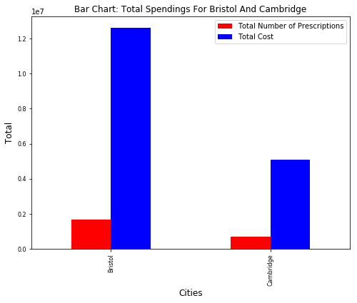

```python
#Create a bar chart to compare the total spendings of Bristol and Cambridge.
ax1 = total_sum.plot(kind='bar', x='Cities', title="Bar Chart: Total Spendings For Bristol And Cambridge", stacked=False, color=['r', 'b'], figsize=(8,6), legend=True, fontsize=8)
ax1.set_xlabel("Cities",fontsize=12)
ax1.set_ylabel("Total",fontsize=12)
ax1.legend(loc='upper right')
```

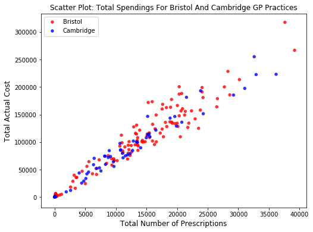

```python
#Create a scatter plot to compare the total spendings of each GP practice in Bristol and Cambridge.
bristol_total = (bristol_df2['Total Number of Prescriptions'], bristol_df2['Total Actual Cost'])
cambridge_total = (cambridge_df2['Total Number of Prescriptions'], cambridge_df2['Total Actual Cost'])

data = (bristol_total, cambridge_total)
colours = ("red", "blue")
groups = ("Bristol", "Cambridge")


fig = plt.figure(figsize=(8, 6))
ax2 = fig.add_subplot(1, 1, 1, axisbg="1.0")

for data, color, group in zip(data, colours, groups):
    x, y = data
    ax2.scatter(x, y, alpha=0.8, c=color, edgecolors='none', s=30, label=group)

ax2.set_xlabel("Total Number of Prescriptions",fontsize=12)
ax2.set_ylabel("Total Actual Cost",fontsize=12)

plt.title('Scatter Plot: Total Spendings For Bristol And Cambridge GP Practices')
plt.legend(loc=2)
plt.show()
```

### Question 5: Using SQL, produce a table that provides the number of GP practices per city, ordered in descending order.

```python
#Install pandasql.
!pip install pandasql
```

```python
#SQL preliminaries.
from pandasql import PandaSQL
pdsql = PandaSQL()
```

```python
#Rename the column 'Address 3' to 'Address_3' in practices_df.
practices_df = practices_df.rename(index=str, columns={"Address 3": "Address_3"})
```

```python
#SQL execution command to tabulate the number of GP practices per city, ordered in descending order.
sql_data = """SELECT Address_3, COUNT(*) FROM practices_df GROUP BY Address_3 ORDER BY COUNT(*) DESC"""

print (pdsql(sql_data).head())
```

```
                   Address_3  COUNT(*)
0                                  339
1  BIRMINGHAM                      173
2  LIVERPOOL                       137
3  LEEDS                           122
4  MANCHESTER                      117
```

# Assignment B

### Question 1: Calculate the monthly total spending for each GP-practice.

```python
#Group merged dataframe by 'Practice' and 'Practice Name'.
prescribing_df1 = merged.groupby(['Practice', 'Practice name'], as_index=False).sum()

#Tabulate the monthly total spending for each GP practice.
monthly_spending = pd.DataFrame({'Practice' : pd.Categorical(prescribing_df1['Practice']),
                                 'Practice Name' : pd.Categorical(prescribing_df1['Practice name']),
                                 'Total Cost Per Practice' : pd.Series(prescribing_df1['Act Cost'])})

monthly_spending  = monthly_spending[['Practice', 'Practice Name', 'Total Cost Per Practice']]
monthly_spending.head()
```

|  | Practice | Practice Name | Total Cost Per Practice |
| --- | --- | --- | --- |
| 0 | A81001 | THE DENSHAM SURGERY | 83220.57 |
| 1 | A81002 | QUEENS PARK MEDICAL CENTRE | 333514.67 |
| 2 | A81003 | VICTORIA MEDICAL PRACTICE | 47977.16 |
| 3 | A81004 | WOODLANDS ROAD SURGERY | 147494.85 |
| 4 | A81005 | SPRINGWOOD SURGERY | 107669.51 |

### Question 2: Use the number of registered patients in each GP-practice to calculate the relative costs per patient.

```python
#Merge monthly_spending and demoinfo_df.
merged2 = pd.merge(monthly_spending, demoinfo_df[['GP_PRACTICE_CODE', 'POSTCODE', 'Total_All']], left_on='Practice' , right_on='GP_PRACTICE_CODE')

#Make a new column for 'COST_PER_PATIENT' in merged2.
merged2['COST_PER_PATIENT'] = (merged2['Total Cost Per Practice'] / merged2['Total_All']).round(2)

#Tabulate the total cost per patient for each GP practice.
cost_per_patient = pd.DataFrame({'Practice' : pd.Categorical(merged2['GP_PRACTICE_CODE']),
                                 'Practice Name' : pd.Categorical(merged2['Practice Name']),
                                 'Total Cost Per Patient' : pd.Series(merged2['COST_PER_PATIENT'])})

cost_per_patient = cost_per_patient[['Practice', 'Practice Name', 'Total Cost Per Patient']]
cost_per_patient.head()
```

|  | Practice | Practice Name | Total Cost Per Patient |
| --- | --- | --- | --- |
| 0 | A81001 | THE DENSHAM SURGERY | 19.66 |
| 1 | A81002 | QUEENS PARK MEDICAL CENTRE | 16.94 |
| 2 | A81003 | VICTORIA MEDICAL PRACTICE | 14.29 |
| 3 | A81004 | WOODLANDS ROAD SURGERY | 16.12 |
| 4 | A81005 | SPRINGWOOD SURGERY | 13.66 |

### Question 3: Visualize the monthly total spending per registered patients for all GP-practices in a scatterplot, show a trend line, and visualize the data for your city within the national scatterplot.

```python
#Identify Bristol GP practices.
bristol_data2 = merged2.loc[merged2['POSTCODE'].str.startswith('BS')]
bristol_data2.head()
```

|  | Practice | Practice Name | Total Cost Per Practice | GP_PRACTICE_CODE | POSTCODE | Total_All | COST_PER_PATIENT |
| --- | --- | --- | --- | --- | --- | --- | --- |
| 4956 | L81004 | PORTISHEAD MEDICAL GROUP | 228511.10 | L81004 | BS20 6AQ | 18183 | 12.57 |
| 4957 | L81006 | THE GREEN PRACTICE AT WHITCHURCH H C | 51891.20 | L81006 | BS14 0SU | 3816 | 13.60 |
| 4958 | L81007 | THE SOUTHVILLE SURGERY | 61316.17 | L81007 | BS3 1AS | 8553 | 7.17 |
| 4959 | L81008 | SHIREHAMPTON GROUP PRACTICE | 128469.59 | L81008 | BS11 9SB | 11307 | 11.36 |
| 4960 | L81009 | STOCKWOOD MEDICAL CENTRE | 158186.32 | L81009 | BS14 8PT | 9360 | 16.90 |

```
(0, 60352)
```

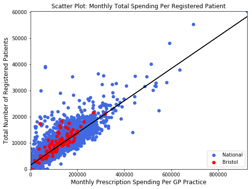

```python
#National data.
x = merged2['Total Cost Per Practice']
y = merged2['Total_All']

#Bristol data.
x_2 = bristol_data2['Total Cost Per Practice']
y_2 = bristol_data2['Total_All']

#Create scatter plot.
fig = plt.figure(figsize=(8, 6))
ax3 = fig.add_subplot(111)

rects1 = ax3.scatter(x, y, color='royalblue')
rects2 = ax3.scatter(x_2, y_2, color='red')
fit = np.polyfit(x, y, deg=1)
ax3.plot(x, fit[0] * x + fit[1], color='black')
ax3.set_title('Scatter Plot: Monthly Total Spending Per Registered Patient')
ax3.set_xlabel("Monthly Prescription Spending Per GP Practice",fontsize=12)
ax3.set_ylabel("Total Number of Registered Patients",fontsize=12)
ax3.legend((rects1, rects2), ('National', 'Bristol'), loc='lower right')

max_x = max(merged2['Total Cost Per Practice'].max(), bristol_data2['Total Cost Per Practice'].max())
max_y = max(merged2['Total_All'].max(), bristol_data2['Total_All'].max())
ax3.set_xlim(0, max_x)
ax3.set_ylim(0, max_y)
```

### Question 4: Visualize the relative costs per patient of all national GP-practices in a histogram.

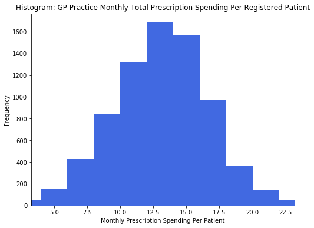

```python
x = cost_per_patient['Total Cost Per Patient'].values

bin_values = np.arange(start=0, stop=(cost_per_patient['Total Cost Per Patient'].max()), step=2)

plt.figure(figsize=(8, 6))
plt.hist(x, bins=bin_values, color='royalblue')
plt.xlabel("Monthly Prescription Spending Per Patient")
plt.ylabel("Frequency")

min_x = cost_per_patient['Total Cost Per Patient'].quantile(.01)
max_x = cost_per_patient['Total Cost Per Patient'].quantile(.99)
plt.xlim(min_x, max_x)
plt.title("Histogram: GP Practice Monthly Total Prescription Spending Per Registered Patient")
plt.show()
```

### Question 5: Use descriptive statistics to show how your assigned city compares to the national level.

```python
#Calculate the cost per patient in Bristol and on the national level.
bristol_totperpatient = (bristol_data2['Total Cost Per Practice'].sum() / bristol_data2['Total_All'].sum()).round(2)
national_totperpatient = (merged2['Total Cost Per Practice'].sum() / merged2['Total_All'].sum()).round(2)

#Tabulate the values.
totperpatient = pd.DataFrame({'Level' : pd.Categorical(["Bristol", "National"]),
                              'Total Cost Per Patient' : pd.Series([bristol_totperpatient, national_totperpatient])})

totperpatient = totperpatient[['Level', 'Total Cost Per Patient']]
totperpatient
```

|  | Level | Total Cost Per Patient |
| --- | --- | --- |
| 0 | Bristol | 12.10 |
| 1 | National | 13.06 |

```
Text(0,0.5,'Total Cost Per Patient')
```

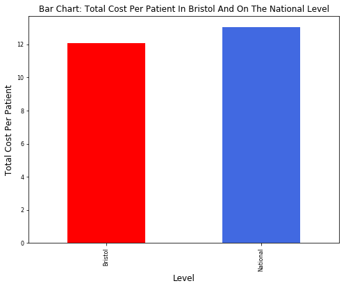

```python
#Create a bar chart to compare the total cost per patient in Bristol and on the national level.
ax4 = totperpatient[['Level', 'Total Cost Per Patient']].plot(kind='bar', x='Level', y='Total Cost Per Patient', title="Bar Chart: Total Cost Per Patient In Bristol And On The National Level", stacked=False, color=['red', 'royalblue'], figsize=(8,6), legend=False, fontsize=8)
ax4.set_xlabel("Level",fontsize=12)
ax4.set_ylabel("Total Cost Per Patient",fontsize=12)
```

# Assignment C

### Question 1: Identify the relative costs per patient for all statin prescriptions (simvastation, atorvastatin, rosuvastatin, pravastatin, fluvastatin) by using the dataset from December 2015.

```python
#Group prescribing_df by 'BNF Name'.
prescribing_df2 = prescribing_df.groupby('BNF Name', as_index=False).sum()
```

```python
#Create dataframes by selecting data in prescribing_df2 containing each statin prescription.
atorvastatin_data = prescribing_df2.loc[prescribing_df2['BNF Name'].str.contains('Atorvastatin'), ['BNF Name', 'Items', 'Act Cost']]
fluvastatin_data = prescribing_df2.loc[prescribing_df2['BNF Name'].str.contains('Fluvastatin'), ['BNF Name', 'Items', 'Act Cost']]
pravastatin_data = prescribing_df2.loc[prescribing_df2['BNF Name'].str.contains('Pravastatin'), ['BNF Name', 'Items', 'Act Cost']]
rosuvastatin_data = prescribing_df2.loc[prescribing_df2['BNF Name'].str.contains('Rosuvastatin'), ['BNF Name', 'Items', 'Act Cost']]
simvastatin_data = prescribing_df2.loc[prescribing_df2['BNF Name'].str.contains('Simvastatin'), ['BNF Name', 'Items', 'Act Cost']]

#Add a new column 'Statin' in each dataframe.
atorvastatin_data['Statin'] = "Atorvastatin"
fluvastatin_data['Statin'] = "Fluvastatin"
pravastatin_data['Statin'] = "Pravastatin"
rosuvastatin_data['Statin'] = "Rosuvastatin"
simvastatin_data['Statin'] = "Simvastatin"

#Combine the dataframes.
statins_data = atorvastatin_data.append([fluvastatin_data, pravastatin_data, rosuvastatin_data, simvastatin_data])
```

```python
#Group statins_data by 'Statin'.
statins_data2 = statins_data.groupby('Statin', as_index=False).sum()

#Add a new column 'Cost Per Patient' in statins_data2.
statins_data2['Cost Per Patient'] = (statins_data2['Act Cost'] / statins_data2['Items']).round(2)

#Tabulate the total cost per patient for each statin prescription.
statins_data3 = pd.DataFrame({'Statin' : pd.Categorical(statins_data2['Statin']),
                              'Total Cost Per Patient' : pd.Series(statins_data2['Cost Per Patient'])})

statins_data3 = statins_data3[['Statin', 'Total Cost Per Patient']]
statins_data3
```

|  | Statin | Total Cost Per Patient |
| --- | --- | --- |
| 0 | Atorvastatin | 1.78 |
| 1 | Fluvastatin | 6.21 |
| 2 | Pravastatin | 1.73 |
| 3 | Rosuvastatin | 22.92 |
| 4 | Simvastatin | 1.28 |

### Question 2: Identify for all GP-practice the associated Index of Multiple Deprivation (IMD) for each GP-Practice in your assigned city.

```python
#Merge practices_df and EDI_df.
merged3 = pd.merge(practices_df[['Practice', 'Practice name', 'Postcode']], EDI_df)

#Identify Bristol GP practices.
bristol_data3 = merged3.loc[merged3['Postcode'].str.startswith('BS')]

#Drop duplicates.
bristol_sorted2 = bristol_data3.drop_duplicates(subset=['Practice'], keep='first', inplace=False)
bristol_sorted2[['Practice', 'Practice name', 'Index of Multiple Deprivation Rank']].head()
```

|  | Practice | Practice name | Index of Multiple Deprivation Rank |
| --- | --- | --- | --- |
| 7408 | L81004 | PORTISHEAD MEDICAL GROUP | 24153.0 |
| 7409 | L81006 | THE GREEN PRACTICE AT WHITCHURCH H C | 21556.0 |
| 7411 | L81031 | THE ARMADA FAMILY PRACTICE | 21556.0 |
| 7413 | L81007 | THE SOUTHVILLE SURGERY | 3579.0 |
| 7414 | L81008 | SHIREHAMPTON GROUP PRACTICE | 7510.0 |